# SDS 220 Final Project

Author

Sarah Susnea, Kiran Das-Goel

Published

May 11, 2023

# Introduction:

The book publishing industry has become a monopoly. Where once many different publishers competed to provide the best content to readers and the best care to authors, now the industry is comprised of five giants. 60% of all published books are owned by Penguin Random House, Hachette Book Group, Harper Collins, Simon & Schuster, or Macmillan (McCabe 2022). In 2013, Penguin Publishing acquired Random House Publishing, becoming the largest publisher in the United States.

The United States government is currently suing to stop Penguin Random House from buying Simon & Schuster. If the deal was to go through, the Biden administration worries Penguin Random House will dominate the industry, impacting price listing and stifling free competition. Industry analysts say that the combined company would control the market, as Penguin book titles accounted for 38% of the top 100 best selling print books(Crumm 2022). Simon & Schuster makes up 11%. However, Penguin argues that the acquisition is actually a protective move against Amazon. Currently authors and smaller publishers lack control over Amazon pricing. Penguin argues that the deal would allow them leverage over Amazon, ensuring their authors are protected from exploitation and their books sold at fair prices and terms. Essentially, Penguin Random House believes that in order to protect the market from monopolization by Amazon, they need to monopolize the market first.

Our project investigates the question of publisher affecting a book’s list price by conducting a two sample t-test on a sample of books. When we first designed our experiment, we wanted to conduct a regression model with a permutation test. However, early into our analysis, we realized that we had set up an incompatible experiment. We were running into problems when trying to do a permutation test with a multimodal categorical variable. So given our research question, we switched our experiment method to t-tests comparing the difference of means.

# Exploratory Data Analysis:

| Publisher | Count | Avg List Price | Standard Deviation |
| --- | --- | --- | --- |
| Hachette | 18 | 13.23444 | 2.822530 |
| Harper | 27 | 14.83556 | 2.551668 |
| Macmillan | 12 | 15.69833 | 5.894051 |
| Other | 56 | 26.84429 | 27.312503 |
| Penguin | 97 | 14.20948 | 3.567602 |
| Simon | 24 | 12.62792 | 3.878229 |

From this table, we can observe that Penguin Random House was the most frequently represented publisher while having a mean price that was neither the priciest or cheapest. We also observed that Macmillan, the publisher with the highest average price, was only represented 12 times. While it is true that Macmillan does have some pricier books, these books affect the mean more significantly because there are fewer observations. Penguin Random House, on the other hand, may also sell expensive books but these prices are balanced out by the quantity of books priced at significantly lower price points.

We were also surprised by the Other category’s high average price and standard deviation.

We continued our investigation by looking at the distribution of the list prices of the books with our publisher variable mapped to color. In Figure 1, we excluded books over $45. Here we can observe that the majority of the books in our data set, especially those sold by Penguin, were priced at a range of $5 to $15. We also noticed that fewer books were placed at higher list prices.

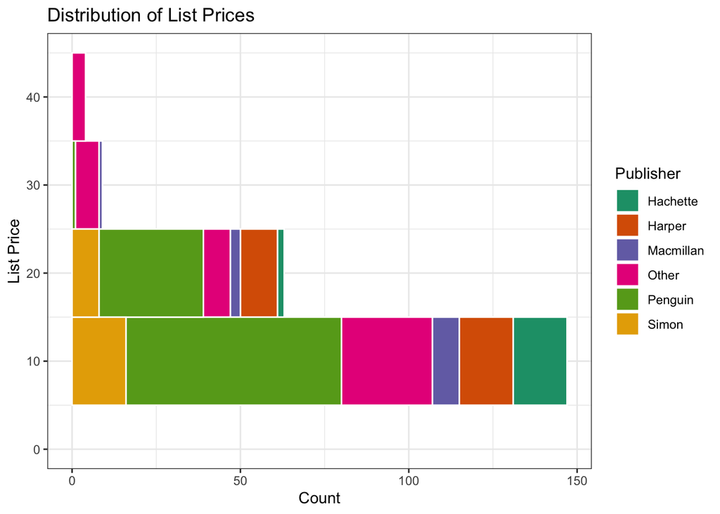

Figure 1: Histogram showing the number of books at different prices differentiated by color.

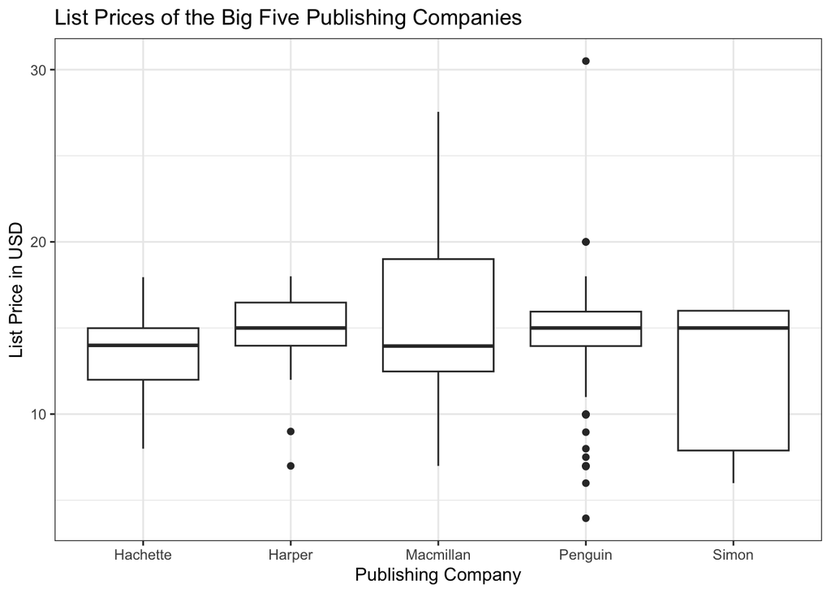

Figure 2: Distribution of book prices broken down by Big Five Publisher.

Because we were interested in investigating Amazon prices as well, we created Figure 3, a scatter plot that visualizes the relationship between a book’s list price and and its Amazon price. We observed that most books were clustered around a list price of $15 and an Amazon price of $10. Across most of our books we noticed lower Amazon prices when compared to list prices.

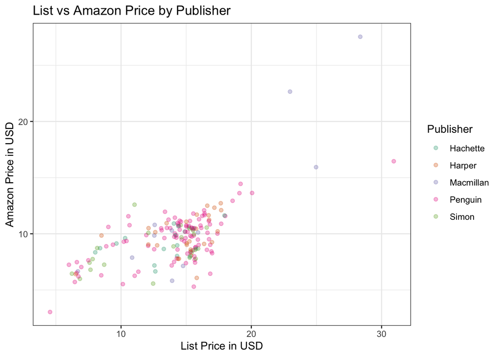

Figure 3: Scatter plot showing list price versus Amazon price with publisher distinguished by color.

# Results:

To conduct our hypothesis test, we ended up computing t-statistics based on the difference in average list price between each of the Big Five publishers and the remaining publishers in the data set. For example, our first t-test compared the difference in average list price for books published by Hachette to the average list price for all other books in the data set. The outcomes of these t-tests are visualized in the figures below.

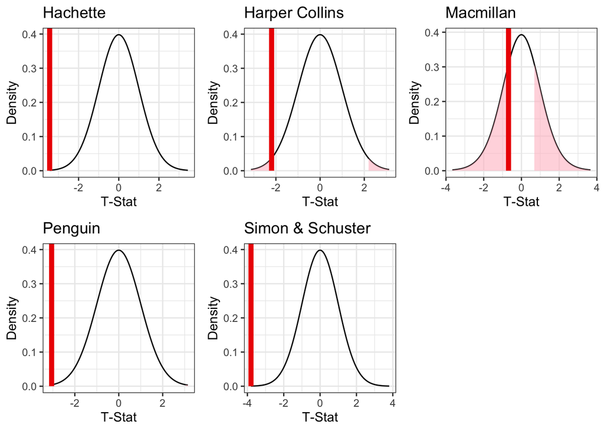

Figure 4: T-distributions with two directional p-values shaded for each t-statistic calculated

[output not shown]

To reiterate, our research question was as follows: does publishing company affect a book’s list price?

Each of our hypothesis tests, except for Macmillan’s, showed us that t-statistics that were highly unlikely to occur assuming that each publisher’s average list price is the same as the rest of the publishing industries.

We assumed $\alpha = 0.05$ so we rejected the null hypothesis that each publisher’s average list price is the same as the rest of the publishing industries. The one exception to this was for book’s published by Macmillan where we recorded a p-value of $0.45$. This means that for all of the publishers aside from Macmillan, we have the evidence to conclude that there is a relationship between publisher and list price of a book.

# Discussion:

## Conclusions:

We found that there is a relationship between publisher and list price. Our experiment demonstrates that Big Five price listings are under the average for the publishing industry. However, part of the reason our t-stats were so negative is due to our research design. We calculated our t-stats by subtracting global average price from publisher price average. Since there were some books in the data set that were significantly more expensive than others, it makes sense that our t-stats were all negative. Due to some expensive outliers owned by independent publishers, our global mean will always be higher than the Big Five means.

Our research implies that Big Five Publishers are able to undercut the market. This means that if the Penguin Random House and Simon and Schuster deal goes through, the publishing giant could pose a significant threat to industry competition. Smaller publishers may get priced out due to the merger. If authors want their books to become bestsellers, they must be published through a Big Five publisher, even if this means lower royalties and worse treatment. Additionally, this shows us that Penguin’s initial claims hold true: bigger publishers do have more control over price listings.

## Limitations:

While our data set allowed us to answer our research question, we found the data to be lacking. Even though we were able to draw conclusions about our specific sample, we felt that the results we produced were not tested enough to make generalizations about the publishing industry. This may be due to how we constructed our research question and hypothesis test, but as we were conducting our tests, we wished that the data was more standardized or recorded more variables. Discrepancies or differences in price may arise due to differences in books like genre. A fiction book for elementary aged children will naturally be placed at a different price point than a manual on how to restore a tractor. We would have been able to control for these variables in our sample if the data had recorded this information. Maybe then we could have been able to determine if one publisher dominates a corner of the market.

## Further Questions:

One can make the case that there are more variables that affect a book’s price. While we controlled one of those variables by excluding hardcover books from our data, book length is another variable that factors into a book’s price. In Figure 6, we investigated this relationship by looking at a book’s length and its price. Future research, in addition to considering things like a book’s genre or demographic, could even control for the number of pages in a book.

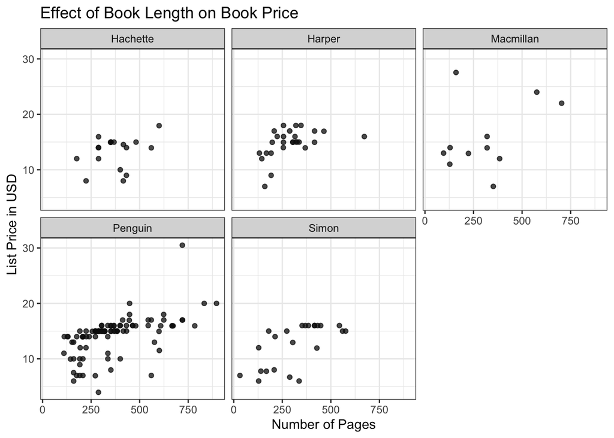

Figure 6: Scatterplots showing the relationship between book length and list price.

## Appendix:

Normality assumption:

[figure not shown]

To test equal variance, we can look back at Figure 2 where we notice that none of our categories have the same variance Here we notice a violation of the equal variance assumption. It is important to note, however, that the `infer` package which we used to conduct our t-tests adjusts for this violation.

Thus we are confident that our experiment method can be reasonably and reliably applied to this data.

## Bibliography:

Crumm, David. 2022. “What Are Big Five Publishers? And Does It Matter If They Become Big Four?” https://frontedgepublishing.com/what-are-the-big-five-publishers-and-why-does-a-penguin-random-house-and-simon-schuster-merger-matter/.

McCabe, David. 2022. “Will the Biggest Publisher in the United States Get Even Bigger?” https://www.nytimes.com/2022/07/31/books/penguin-random-house-simon-schuster-antitrust-trial.html.